# Oniona DateWise Analysis

# Frame

Question to be answered 1.which city has the highest sale of onion in a year? 2.predict the price of onion for the next 30 days?

# Acquire

```r
#library(rvest)
#Read the data from the file
#pg.out<-read_html("DailyWiseMarketArrivals.htm")
#pg.out %>%
 #    html_node('#dnn_ctr966_DailyWiseMarketArrivals_GridView1') %>%
  #   html_table()
df=read.csv("DailyWiseMarketArrivals.csv",header=TRUE)
str(df)
```

```
'data.frame':   6582 obs. of  6 variables:
 $ Date                : Factor w/ 120 levels "","01/Apr/2017",..: 8 8 12 16 24 28 36 40 44 48 ...
 $ Market              : Factor w/ 135 levels "ABOHAR(PB)","AGRA(UP)",..: 1 2 2 2 2 2 2 2 2 2 ...
 $ Arrival.q.          : int  200 2850 2950 3400 3800 3700 3300 3500 3150 3100 ...
 $ Price.Minimum..Rs.q.: Factor w/ 236 levels "0","100","1000",..: 188 172 198 193 188 188 198 188 198 198 ...
 $ Price.Maximum..Rs.q.: Factor w/ 386 levels "0","1000","1010",..: 2 369 363 363 345 345 363 359 363 363 ...
 $ Modal.Price..Rs.q.  : Factor w/ 338 levels "0","1000","1007",..: 285 285 282 279 268 270 282 276 282 285 ...
```

```r
#pg.table
```

# Refine

Refine the received raw data into fine data for the analysis

Step1: ***************************************************************************** -Rename the column name as it is long so assigning new name to column *****************************************************************************

```r
newnames<-c('date','market','quantity','pricemin','pricemax','pricemod')
colnames(df)<-newnames
head(df)
```

|  | date | market | quantity | pricemin | pricemax | pricemod |
| --- | --- | --- | --- | --- | --- | --- |
| 1 | 02/Jan/2017 | ABOHAR(PB) | 200 | 750 | 1000 | 850 |
| 2 | 02/Jan/2017 | AGRA(UP) | 2850 | 600 | 925 | 850 |
| 3 | 03/Jan/2017 | AGRA(UP) | 2950 | 800 | 900 | 840 |
| 4 | 04/Jan/2017 | AGRA(UP) | 3400 | 780 | 900 | 830 |
| 5 | 06/Jan/2017 | AGRA(UP) | 3800 | 750 | 850 | 800 |
| 6 | 07/Jan/2017 | AGRA(UP) | 3700 | 750 | 850 | 810 |

Step2: ***************************************************************** -Remove the last row as it contains the total of all the data ******************************************************************

```r
library(dplyr)
df<-df %>%
  filter(market!='Total')
tail(df)
```

|  | date | market | quantity | pricemin | pricemax | pricemod |
| --- | --- | --- | --- | --- | --- | --- |
| 6576 | 21/Apr/2017 | YEOLA(MS) | 17000 | 250 | 576 | 425 |
| 6577 | 22/Apr/2017 | YEOLA(MS) | 10477 | 200 | 633 | 440 |
| 6578 | 24/Apr/2017 | YEOLA(MS) | 23189 | 200 | 601 | 450 |
| 6579 | 25/Apr/2017 | YEOLA(MS) | 5000 | 200 | 622 | 400 |
| 6580 | 27/Apr/2017 | YEOLA(MS) | 5000 | 150 | 490 | 390 |
| 6581 | 29/Apr/2017 | YEOLA(MS) | 20000 | 151 | 538 | 375 |

Step3: ************************************************************** -change the data type of the columns **************************************************************

```r
library(dplyr)
df$date<-as.Date(df$date, format = "%d/%b/%Y")
df$market<-as.character(df$market)
df$pricemin<-as.numeric(as.character(df$pricemin))
df$pricemax<-as.numeric(as.character(df$pricemax))
df$pricemod<-as.numeric(as.character(df$pricemod))
#str(df)
#df$year<-as.numeric(df$year)
#df$pricemin<-as.numeric(df$pricemin)
#df$pricemax<-as.numeric(df$pricemax)
#df$pricemod<-as.numeric(df$pricemod)
str(df)
```

```
'data.frame':   6581 obs. of  6 variables:
 $ date    : Date, format: "2017-01-02" "2017-01-02" "2017-01-03" ...
 $ market  : chr  "ABOHAR(PB)" "AGRA(UP)" "AGRA(UP)" "AGRA(UP)" ...
 $ quantity: int  200 2850 2950 3400 3800 3700 3300 3500 3150 3100 ...
 $ pricemin: num  750 600 800 780 750 750 800 750 800 800 ...
 $ pricemax: num  1000 925 900 900 850 850 900 880 900 900 ...
 $ pricemod: num  850 850 840 830 800 810 840 820 840 850 ...
```

```r
#head(df)
```

step4:

–Retrive the state name as city and state name is combined *************************************************************

```r
library(tidyr)
str(df)
```

```
'data.frame':   6581 obs. of  6 variables:
 $ date    : Date, format: "2017-01-02" "2017-01-02" "2017-01-03" ...
 $ market  : chr  "ABOHAR(PB)" "AGRA(UP)" "AGRA(UP)" "AGRA(UP)" ...
 $ quantity: int  200 2850 2950 3400 3800 3700 3300 3500 3150 3100 ...
 $ pricemin: num  750 600 800 780 750 750 800 750 800 800 ...
 $ pricemax: num  1000 925 900 900 850 850 900 880 900 900 ...
 $ pricemod: num  850 850 840 830 800 810 840 820 840 850 ...
```

```r
unique(df$market)
```

```
  [1] "ABOHAR(PB)"               "AGRA(UP)"                 "AHMEDABAD(GUJ)"
  [4] "AHMEDNAGAR(MS)"           "AIGINIA MANDIA (OR)"      "AJMER(RAJ)"
  [7] "ALIGARH(UP)"              "ALLAHABAD(UP)"            "ALWAR(RAJ)"
 [10] "AMRITSAR(PB)"             "ASANSOL (WB)"             "AURANGABAD(MS)"
 [13] "BALLIA(UP)"               "BANGALORE"                "BAREILLY(UP)"
 [16] "BELGAUM(KNT)"             "BHATINDA(PB)"             "BHAVNAGAR(GUJ)"
 [19] "BHOPAL"                   "BHUBNESWER(OR)"           "BIJAPUR(KNT)"
 [22] "BINNY MILL (KNT)"         "BOMBORI(MS)"              "BOWENPALLY(Telangana)"
 [25] "BURDWAN(WB)"              "CHAKAN(MS)"               "CHANDIGARH"
 [28] "CHANDRAPUR-GANJWAD (MS)"  "CHANDVAD(MS)"             "CHENNAI"
 [31] "CHICKBALLAPUR(KNT)"       "DEESA(GUJ)"               "DEHRADOON(UTT)"
 [34] "DELHI"                    "DEORIA(UP)"               "DEVALA(MS)"
 [37] "DHAVANGERE(KNT)"          "DHULIA(MS)"               "DINDIGUL(TN)"
 [40] "DINDIGUL(TN)(Podis"       "DINDORI(MS)"              "ETAH (UP)"
 [43] "ETAWAH(UP)"               "FAIZABAD(UP)"             "FARUKHABAD(UP)"
```

[output cut: 30 more lines]

```r
df<-df %>%
    mutate(market1=market )%>%
    separate(market1,c('city','state'),sep="\\(")
```

```
Too many values at 13 locations: 2258, 2259, 2260, 2261, 2262, 2263, 2264, 2265, 2266, 2267, 2268, 2269, 2270Too few values at 934 locations: 834, 835, 836, 837, 838, 839, 840, 841, 842, 843, 844, 845, 846, 847, 848, 849, 850, 851, 852, 853, ...
```

```r
df$state<-substr(df$state,1,nchar(df$state)-1) #removing thelast ) from state

head(df)
```

|  | date | market | quantity | pricemin | pricemax | pricemod | city | state |
| --- | --- | --- | --- | --- | --- | --- | --- | --- |
| 1 | 2017-01-02 | ABOHAR(PB) | 200 | 750 | 1000 | 850 | ABOHAR | PB |
| 2 | 2017-01-02 | AGRA(UP) | 2850 | 600 | 925 | 850 | AGRA | UP |
| 3 | 2017-01-03 | AGRA(UP) | 2950 | 800 | 900 | 840 | AGRA | UP |
| 4 | 2017-01-04 | AGRA(UP) | 3400 | 780 | 900 | 830 | AGRA | UP |
| 5 | 2017-01-06 | AGRA(UP) | 3800 | 750 | 850 | 800 | AGRA | UP |
| 6 | 2017-01-07 | AGRA(UP) | 3700 | 750 | 850 | 810 | AGRA | UP |

```r
str(df)
```

```
'data.frame':   6581 obs. of  8 variables:
 $ date    : Date, format: "2017-01-02" "2017-01-02" "2017-01-03" ...
 $ market  : chr  "ABOHAR(PB)" "AGRA(UP)" "AGRA(UP)" "AGRA(UP)" ...
 $ quantity: int  200 2850 2950 3400 3800 3700 3300 3500 3150 3100 ...
 $ pricemin: num  750 600 800 780 750 750 800 750 800 800 ...
 $ pricemax: num  1000 925 900 900 850 850 900 880 900 900 ...
 $ pricemod: num  850 850 840 830 800 810 840 820 840 850 ...
 $ city    : chr  "ABOHAR" "AGRA" "AGRA" "AGRA" ...
 $ state   : chr  "PB" "UP" "UP" "UP" ...
```

step5: ********************************************************************************* –update the state code where state code is not mentioned hardcoding the value *********************************************************************************

```r
head(df)
```

[output not shown]

```r
df$state=ifelse(df$city=='BANGALORE','KNT',df$state)
df$state=ifelse(df$city=='CHENNAI','TN',df$state)
df$state=ifelse(df$city=='DELHI','DL',df$state)
df$state=ifelse(df$city=='BHOPAL','MP',df$state)
df$state=ifelse(df$city=='CHANDIGARH','CH',df$state)
df$state=ifelse(df$city=='GUWAHATI','AS',df$state)
df$state=ifelse(df$city=='HYDERABAD','TELANGANA',df$state)
df$state=ifelse(df$city=='JAIPUR','RAJ',df$state)
df$state=ifelse(df$city=='JAMMU','JK',df$state)
df$state=ifelse(df$city=='KOLKATA','WB',df$state)
df$state=ifelse(df$city=='LUCKNOW','UP',df$state)
df$state=ifelse(df$city=='MUMBAI','MS',df$state)
df$state=ifelse(df$city=='NAGPUR','MS',df$state)
df$state=ifelse(df$city=='PATNA','BHR',df$state)
df$state=ifelse(df$city=='SHAHJAHANPUR','UP',df$state)
df$state=ifelse(df$city=='TIPHRA','CG',df$state)
df$state=ifelse(df$city=='BANGALORE','KNT',df$state)
```

Step6: *************************************************************************************** –function to convert the state code into the state name and add the column to dataframe ****************************************************************************************

```r
stateFromStateCode <-function(x)
{
  st.codes<-data.frame(

    state=as.factor(c("AN", "AP", "AR", "AS", "BHR", "CH", "CG", "DN", "DD", "DL",    "GA","GUJ","HR","HP","JK","JH","KNT","KER","LD","MP","MS","MN","ML","MZ","NL","OD","PY","PB","RAJ","SK","TN","TELANGANA","TR","UK","UP","WB")),

    fullName=as.factor(c("Andaman and Nicobar Islands","Andhra Pradesh","Arunachal Pradesh","Assam","Bihar","Chandigarh","Chhattisgarh","Dadra and Nagar Haveli","Daman and Diu","Delhi","Goa","Gujrat","Haryana","Himachal Pradesh","Jammu and Kashmir","Jharkhand","Karnataka","Kerala","Lakshadweep","Madhya Pradesh","Maharashtra","Manipur","Meghalaya","Mizoram","Nagaland","Odisha","Puducherry","Punjab","Rajasthan","Sikkim","Tamil Nadu","Telangana","Tripura","Uttarakhand","Uttar Pradesh","West Bengal"))

                         )

   #create an  data.frame of state codes from source column
    st.x<-data.frame(state=x)
    #match source codes with codes from 'st.codes' local variable and use to return the full state name
    refac.x<-st.codes$full[match(st.x$state,st.codes$state)]
    #return the full state names in the same order in which they appeared in the original source
    return(refac.x)

}
df$StateName<-stateFromStateCode(df$state)
```

# Transform

–find the maximum sales quantity by grouping the data together based on state ****************************************************************

```r
# change the data type of statename
df$StateName<-as.character(df$StateName)
# sum the quantity of state wise
dfState <-df %>%
  group_by(StateName) %>%
  summarise(quantity_state=sum(quantity)) %>%
  arrange(desc(quantity_state))

#taking only first 6 date
dfState <- head(dfState)
```

# Explore

–Find the satate having the maximum sales quantity by histograph *******************************************************************

```r
library(ggplot2)
statePlot<-ggplot(dfState)+
aes(reorder(StateName,quantity_state),weight=quantity_state) +
geom_bar()+
  coord_flip()
library(plotly)
ggplotly(statePlot)
```

[interactive chart not shown]

step2: ************************************************************* –show the value in the map *************************************************************

```r
library(ggmap)
#geocode("KNT
#dfState<- dfState %>%
 #         filter(state!="NA")
geo<-geocode(dfState$StateName)
str(geo)
```

```
'data.frame':   6 obs. of  2 variables:
 $ lon: num  75.7 71.2 75.7 80.9 87.9 ...
 $ lat: num  19.8 22.3 15.3 26.8 23 ...
```

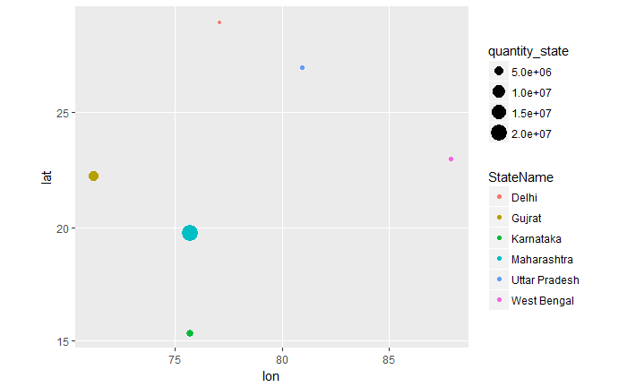

```r
dfStateGeo<-bind_cols(dfState,geo)
ggplot(dfStateGeo) +
  aes(lon,lat,size=quantity_state,color=StateName) +
  geom_point()+
 coord_map()
```

```r
map<-get_map("India",maptype = "watercolor",source = "stamen",zoom=5)
```

[output not shown]

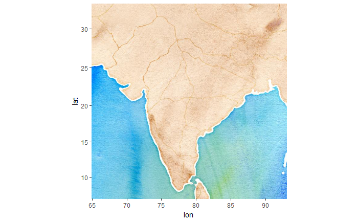

```r
ggmap(map)
```

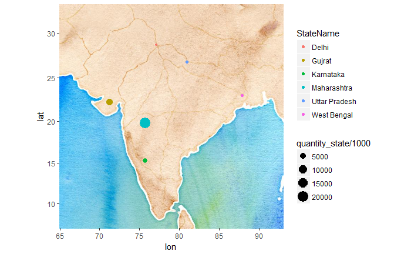

```r
ggmap(map)+geom_point(data=dfStateGeo,aes(lon,lat,size=quantity_state/1000,color=StateName))
```

# transform 2

—since MS(Maharastra data is maximum one,so predict the price) *****************************************************************

```r
dim(df)
```

```
[1] 6581    9
```

```r
dfMaharastra<-df %>%
  filter(StateName =="Maharashtra")
#ggplot(dfMaharastra)+aes(date,pricemin,color=state)+geom_line()
dfTall <- dfMaharastra %>%
        gather("priceType","priceValue",4:6)
head(dfTall)
```

|  | date | market | quantity | city | state | StateName | priceType | priceValue |
| --- | --- | --- | --- | --- | --- | --- | --- | --- |
| 1 | 2017-01-16 | AHMEDNAGAR(MS) | 48516 | AHMEDNAGAR | MS | Maharashtra | pricemin | 100 |
| 2 | 2017-01-23 | AHMEDNAGAR(MS) | 38122 | AHMEDNAGAR | MS | Maharashtra | pricemin | 100 |
| 3 | 2017-02-11 | AHMEDNAGAR(MS) | 20014 | AHMEDNAGAR | MS | Maharashtra | pricemin | 100 |
| 4 | 2017-02-13 | AHMEDNAGAR(MS) | 24983 | AHMEDNAGAR | MS | Maharashtra | pricemin | 100 |
| 5 | 2017-02-18 | AHMEDNAGAR(MS) | 22886 | AHMEDNAGAR | MS | Maharashtra | pricemin | 200 |
| 6 | 2017-03-09 | AHMEDNAGAR(MS) | 34405 | AHMEDNAGAR | MS | Maharashtra | pricemin | 200 |

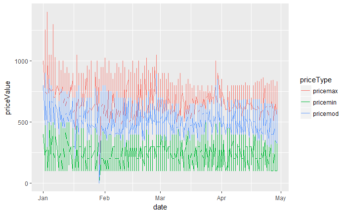

```r
ggplot(dfTall) +
  aes(date,priceValue,color=priceType) +geom_line()
```

```r
#head(dfTall)
```

# Model

—forcast the price max for the next 30 days  
********************************************************

```r
ts <- df %>%
    filter (StateName=="Maharashtra") %>%
    select(date,pricemax)
ts<-head(ts,200)
colnames(ts)<-c('ds','y')
library(prophet)
library(Rcpp)
m <- prophet(ts)
```

```
Disabling yearly seasonality. Run prophet with `yearly.seasonality=TRUE` to override this.
```

```
Initial log joint probability = -2.68431
Optimization terminated normally:
  Convergence detected: absolute parameter change was below tolerance
```

```r
future<-make_future_dataframe(m,periods = 30)
forcast <-predict(m,future)
head(forcast)
```

|  | ds | t | trend | yhat_lower | yhat_upper | trend_lower | trend_upper | seasonal_lower | seasonal_upper | weekly | weekly_lower | weekly_upper | seasonal | yhat |
| --- | --- | --- | --- | --- | --- | --- | --- | --- | --- | --- | --- | --- | --- | --- |
| 1 | 2017-01-02 | 0.000000000 | 742.7673 | 687.4320 | 875.2371 | 742.7673 | 742.7673 | 34.04986 | 34.04986 | 34.04986 | 34.04986 | 34.04986 | 34.04986 | 776.8171 |
| 2 | 2017-01-02 | 0.000000000 | 742.7673 | 685.7074 | 868.2342 | 742.7673 | 742.7673 | 34.04986 | 34.04986 | 34.04986 | 34.04986 | 34.04986 | 34.04986 | 776.8171 |
| 3 | 2017-01-02 | 0.000000000 | 742.7673 | 686.6165 | 870.4982 | 742.7673 | 742.7673 | 34.04986 | 34.04986 | 34.04986 | 34.04986 | 34.04986 | 34.04986 | 776.8171 |
| 4 | 2017-01-03 | 0.008547009 | 739.9334 | 602.9442 | 792.1896 | 739.9334 | 739.9334 | -38.46379 | -38.46379 | -38.46379 | -38.46379 | -38.46379 | -38.46379 | 701.4696 |
| 5 | 2017-01-03 | 0.008547009 | 739.9334 | 608.5334 | 793.9600 | 739.9334 | 739.9334 | -38.46379 | -38.46379 | -38.46379 | -38.46379 | -38.46379 | -38.46379 | 701.4696 |
| 6 | 2017-01-04 | 0.017094017 | 737.0995 | 659.4937 | 844.7924 | 737.0995 | 737.0995 | 14.21640 | 14.21640 | 14.21640 | 14.21640 | 14.21640 | 14.21640 | 751.3159 |

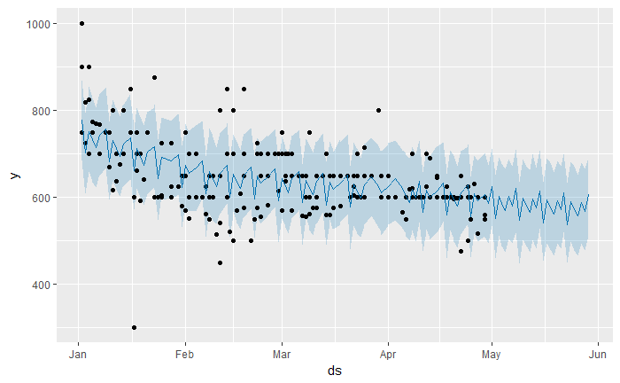

```r
plot(m,forcast)
```